# Corporate default study

Vicente

2023-06-10

## Corporate default study

This project is centered around analyzing a dataset related to the financial health of companies. The dataset consists of various financial and operational variables, providing valuable insights into factors that may contribute to bankruptcy. By examining these variables and their relationships, I aim to uncover patterns and indicators that can assist in predicting the likelihood of a company facing financial distress.

The dataset used in this analysis was collected from reliable proprietary sources, ensuring data integrity and accuracy. It encompasses a wide range of features, including liquidity ratios, profitability measures, debt levels, and other financial metrics. These variables offer a comprehensive view of a company’s financial position and performance.

Throughout the analysis, I will address several key questions. What are the significant predictors of bankruptcy? How do different financial ratios and indicators impact the likelihood of default? Can we build a predictive model to forecast bankruptcy risk accurately? By exploring these questions, I aim to provide valuable insights and actionable recommendations to stakeholders, such as investors, financial institutions, and business analysts.

To analyze the dataset, I employ various statistical and machine learning techniques. This includes exploratory data analysis, feature selection, logistic regression, decision tree models, and ensemble methods. Additionally, I utilize data visualization tools to present findings in a clear and intuitive manner, facilitating better understanding and decision-making.

Some of key accomplishments and capabilities:

Data Cleaning and Manipulation: Using powerful R packages such as tidyverse, dplyr, and purrr, I proficiently cleaned a complex dataset, effectively handling missing and infinite values, and identifying and removing duplicate entries. These steps ensured a clean and accurate dataset, which is the foundation of any data analysis project.

Data Visualization: I have a knack for turning raw data into insightful visualizations. Utilizing the ggplot2 and gridExtra libraries, I created various plots including histograms, bar plots, and box plots to understand the distribution of different variables. Furthermore, I generated a correlation plot, which helped to visualize the relationships between different variables.

Statistical Analysis: I computed descriptive statistics and identified correlations among variables, skillfully dealing with highly correlated variables to avoid multicollinearity in my predictive models.

Model Evaluation: I believe in the importance of robust model evaluation. I calculated the ROC curve and the AUC statistic, widely recognized metrics for binary classification problems, to evaluate the performance of my predictive models. This allowed me to ensure that the models I built were not just statistically significant but also practically useful.

Domain Knowledge: My deep understanding of financial data was crucial in this project. I worked with financial data and developed insightful visualizations and models based on variables such as debt to EBITDA ratio, net worth/assets, and default status.

Here are descriptions for each variable:

cash_assets: This variable represents the ratio of a company’s cash to its total assets. It gives an indication of the company’s liquidity and its ability to cover its short-term liabilities.

debt_ebitda: This variable is the ratio of a company’s debt to its earnings before interest, taxes, depreciation, and amortization (EBITDA). It is used to measure a company’s ability to pay off its incurred debt.

debt_assets: This variable is the ratio of a company’s total debt to its total assets. It provides a measure of the company’s financial leverage and risk.

roe: This stands for Return on Equity. It measures the financial performance of a company by dividing net income by shareholder’s equity. It indicates how well a company is using its equity to generate profits.

roa: This stands for Return on Assets. It measures how efficiently a company is using its assets to generate earnings. It’s calculated by dividing net income by total assets.

intger_debt: Internal cash generation / debt, a measure of a firm’s ability to service its debt.

size: This variable represents the size of the company in terms of its total assets.

cap_debt: This variable represents the capital structure of the firm, specifically the proportion of debt in the company’s capital structure.

nw_assets: This variable represents the ratio of net worth to total assets. It’s a measure of a company’s financial stability and efficiency.

liab_assets: This variable represents the ratio of total liabilities to total assets. It provides an indication of the financial risk of the company.

intger_netdebt: Internal cash generation / debt, but with net debt (total debt - cash and cash equivalents) instead of total debt.

int_cov: This variable likely stands for Interest Coverage, which is the ratio of a company’s EBITDA to its interest expenses. It indicates how easily a company can pay interest on its outstanding debt.

prftmrgn: This stands for Profit Margin. It measures how much out of every dollar of sales a company keeps in earnings. It is a measure of the profitability of the company.

liquidity_ratio: This variable is a measure of a firm’s ability to pay off its current liabilities with its current assets. It’s a key indicator of a firm’s financial health.

netdebt_intger: Ratio of net debt to the company’s EBITDA, another measure of a company’s ability to pay its debts.

intger_debt2: Another measure of a company’s ability to pay its interest expenses.

cash_currntliab: This variable represents the ratio of a company’s cash to its current liabilities. It’s a measure of a company’s short-term liquidity.

default: This binary variable indicates whether the company has defaulted on its debt or not. A value of 1 would represent a default, and 0 would represent no default.

## Load packages and data

```r
# Load packages

library(ggplot2)
library(dplyr)
library(tidyverse)
library(car)
library(boot)
library(rms)
library(mFilter)
library(gam)
library(caret)
library(pROC)
library(DMwR)
library(fmsb)
library(gridExtra)
library(purrr)
library(bestglm)
library(ggcorrplot)
library(randomForest)
library(kernlab)

setwd("C:\\Users\\vicente\\Desktop\\Data Portfolio\\sme")
df <- read_csv("company_bankruptcy_study.csv")
```

## Cleaning Data and removing highly correlated variables

```r
# Cleaning Data
# Drop rows with NA's
df <- df %>%
  drop_na()

# Remove infinite values
df <- df %>%
  mutate(across(everything(), ~replace(., is.infinite(.), NA)))

# Drop rows with NA's again (this will remove the rows with infinities)
df <- df %>%
  drop_na()

# Duplicated Data
duplicate_rows <- duplicated(df)
print(paste("Number of duplicated records:", sum(duplicate_rows)))
```

```
## [1] "Number of duplicated records: 0"
```

```r
# Now let's get summary statistics
summary <- df %>%
  summary()

print(summary)
```

```
##   cash_assets        debt_ebitda          debt_assets
##  Min.   :0.000000   Min.   :-14224.000   Min.   :0.000007
##  1st Qu.:0.009448   1st Qu.:     0.195   1st Qu.:0.073735
##  Median :0.027551   Median :     1.013   Median :0.189434
##  Mean   :0.061705   Mean   :     0.625   Mean   :0.234238
##  3rd Qu.:0.076146   3rd Qu.:     2.645   3rd Qu.:0.342434
##  Max.   :0.827090   Max.   :  7323.750   Max.   :5.081729
##       roe                  roa            intger_debt             size
##  Min.   :-196.53571   Min.   :-6.35314   Min.   :-6586.500   Min.   : 6.623
##  1st Qu.:   0.02509   1st Qu.: 0.00146   1st Qu.:    0.137   1st Qu.: 9.484
##  Median :   0.14970   Median : 0.03937   Median :    0.520   Median :10.185
##  Mean   :   0.21539   Mean   : 0.05698   Mean   :   16.311   Mean   :10.287
##  3rd Qu.:   0.33376   3rd Qu.: 0.10897   3rd Qu.:    1.827   3rd Qu.:11.017
##  Max.   : 183.87500   Max.   : 7.49872   Max.   :13540.000   Max.   :15.326
##     cap_debt           nw_assets        netdebt_assets      liab_assets
##  Min.   :-162.6000   Min.   :-31.3002   Min.   :-0.82331   Min.   : 0.02231
##  1st Qu.:   0.1224   1st Qu.:  0.1570   1st Qu.: 0.02213   1st Qu.: 0.44803
##  Median :   0.3326   Median :  0.3487   Median : 0.14340   Median : 0.65130
##  Mean   :   0.4309   Mean   :  0.3199   Mean   : 0.17253   Mean   : 0.68007
##  3rd Qu.:   0.6040   3rd Qu.:  0.5520   3rd Qu.: 0.30105   3rd Qu.: 0.84295
##  Max.   : 247.5556   Max.   :  0.9777   Max.   : 5.06758   Max.   :32.30018
##  intger_netdebt        int_cov             prftmrgn
##  Min.   :-910.200   Min.   : -999.990   Min.   :-12.283020
##  1st Qu.:  -0.170   1st Qu.:    0.800   1st Qu.:  0.000917
##  Median :   0.270   Median :    2.050   Median :  0.020083
##  Mean   :   2.875   Mean   :    9.523   Mean   :  0.019285
##  3rd Qu.:   1.077   3rd Qu.:    5.400   3rd Qu.:  0.063898
##  Max.   :7244.667   Max.   :  999.990   Max.   :  1.858268
##   debt_intger        liquidity_ratio  gencap_stdebt       gencap_stdebt_assets
##  Min.   :-3177.000   Min.   : 0.010   Min.   :-5605.500   Min.   :-5.74251
##  1st Qu.:    0.165   1st Qu.: 0.920   1st Qu.:    0.367   1st Qu.:-0.11965
##  Median :    1.019   Median : 1.260   Median :    1.291   Median : 0.02898
##  Mean   :    2.793   Mean   : 1.664   Mean   :   44.746   Mean   : 0.04737
##  3rd Qu.:    3.242   3rd Qu.: 1.900   3rd Qu.:    5.242   3rd Qu.: 0.18833
##  Max.   : 4191.833   Max.   :44.360   Max.   :22341.000   Max.   : 9.38267
##  netdebt_intger       intger_debt2        cash_currntliab       default
##  Min.   :-3161.000   Min.   :-1050.0000   Min.   : 0.00000   Min.   :0.00000
##  1st Qu.:   -0.159   1st Qu.:    0.1252   1st Qu.: 0.02271   1st Qu.:0.00000
##  Median :    0.661   Median :    0.3904   Median : 0.06671   Median :0.00000
##  Mean   :    2.283   Mean   :    0.5202   Mean   : 0.22426   Mean   :0.05263
##  3rd Qu.:    2.731   3rd Qu.:    0.8076   3rd Qu.: 0.19620   3rd Qu.:0.00000
##  Max.   : 3985.000   Max.   :  933.9459   Max.   :10.29964   Max.   :1.00000
```

```r
# Find highly correlated variables
correlation_matrix <- cor(df)
highly_correlated <- findCorrelation(correlation_matrix, cutoff = 0.75)

# Get the names of the highly correlated variables
highly_correlated_names <- colnames(df)[highly_correlated]

# Print out the names
print(highly_correlated_names)
```

```
## [1] "gencap_stdebt_assets" "netdebt_assets"       "nw_assets"
## [4] "gencap_stdebt"        "debt_intger"
```

```r
# Remove highly correlated columns
df <- df[c(-10,-11,-15,-17,-18)]
```

## Check for outliers

```r
# The identification of outliers can be done in several ways, but a common method is to identify values that are too far from the mean or median of the distribution. One common rule is to consider as outliers any value that is further than 1.5 times the interquartile range (IQR) from the quartiles.

# Function to identify outliers for numeric columns
identify_outliers <- function(x) {
  if(is.numeric(x)) {
    qnt <- quantile(x, probs=c(.25, .75), na.rm = T)
    H <- 1.5 * IQR(x, na.rm = T)
    return(sum(x < qnt[1] - H | x > qnt[2] + H, na.rm = TRUE))
  } else {
    return(NA)
  }
}

# Apply function to all columns of df and print the result
sapply(df, identify_outliers)
```

```
##     cash_assets     debt_ebitda     debt_assets             roe             roa
##             704            1203             155            1077             894
##     intger_debt            size        cap_debt       nw_assets  intger_netdebt
##            1292              79             325             211            1897
##         int_cov        prftmrgn liquidity_ratio  netdebt_intger    intger_debt2
##            1114            1326             634            1385             752
## cash_currntliab         default
##             962             430
```

## Create a correlation plot

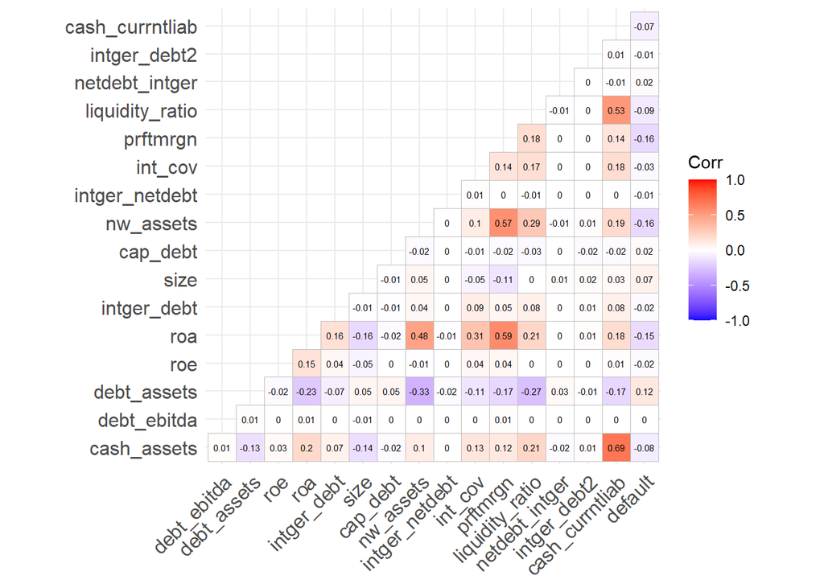

```r
# Create a correlation plot
df %>%
  cor(use = "all.obs") %>%
  ggcorrplot(show.diag = F, type = "lower", lab = TRUE, lab_size=2)
```

## Generate histograms for each variable

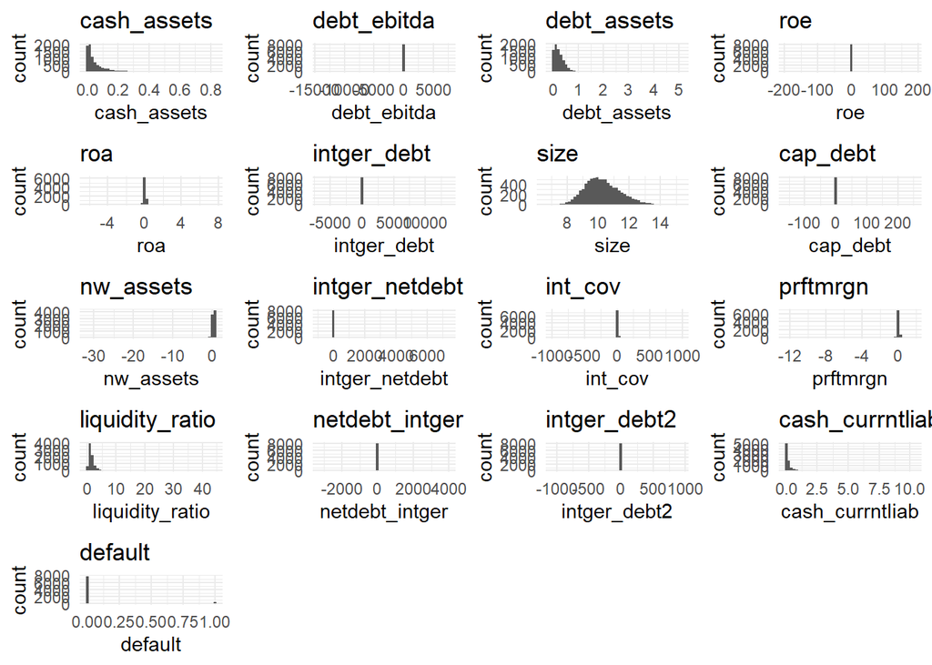

```r
# List of histograms for each column
hist_list <- map(names(df), function(col) {
  ggplot(df, aes_string(col)) +
    geom_histogram(bins = 50) +
    theme_minimal() +
    ggtitle(col)
})

# Arrange plots in a grid
do.call("grid.arrange", c(hist_list, ncol = 4))
```

## Plotting distributions of numeric variables

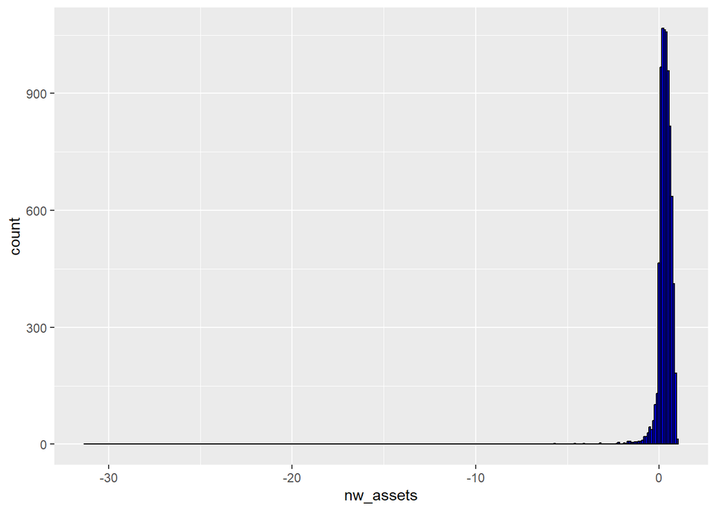

```r
# Plotting distributions of numeric variables
ggplot(df, aes(x = nw_assets)) + geom_histogram(binwidth = 0.1, fill = "blue", color = "black")
```

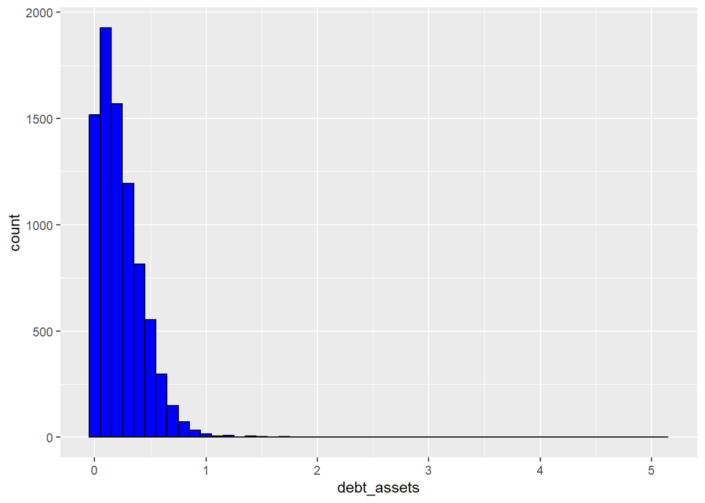

```r
ggplot(df, aes(x = debt_assets)) + geom_histogram(binwidth = 0.1, fill = "blue", color = "black")
```

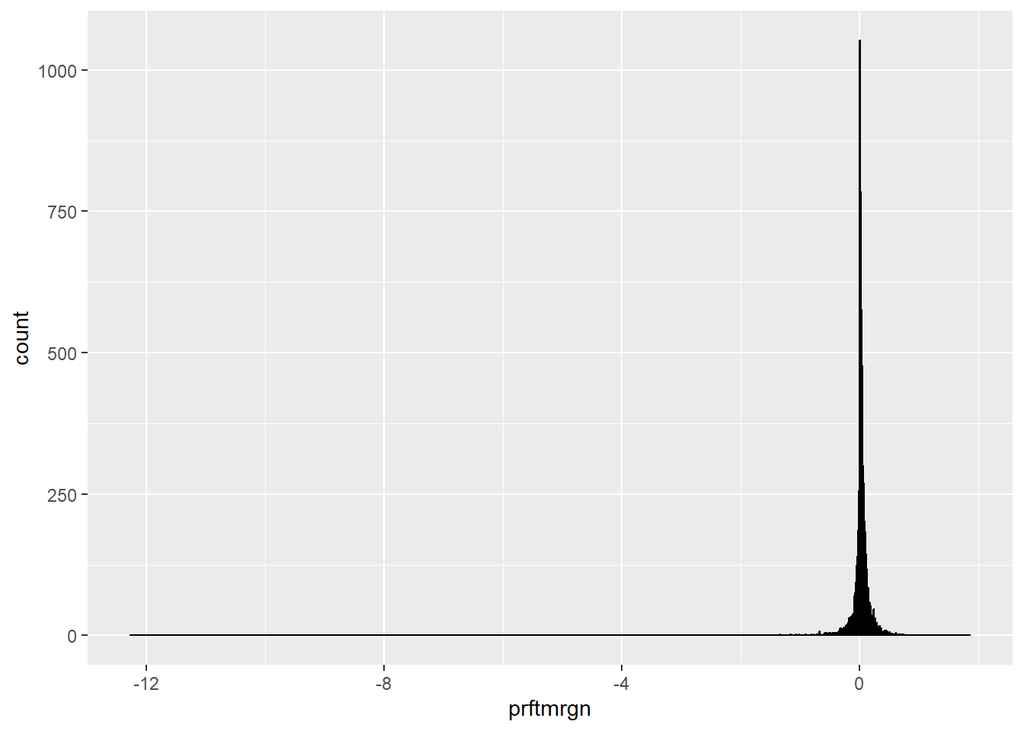

```r
ggplot(df, aes(x = prftmrgn)) + geom_histogram(binwidth = 0.01, fill = "blue", color = "black")
```

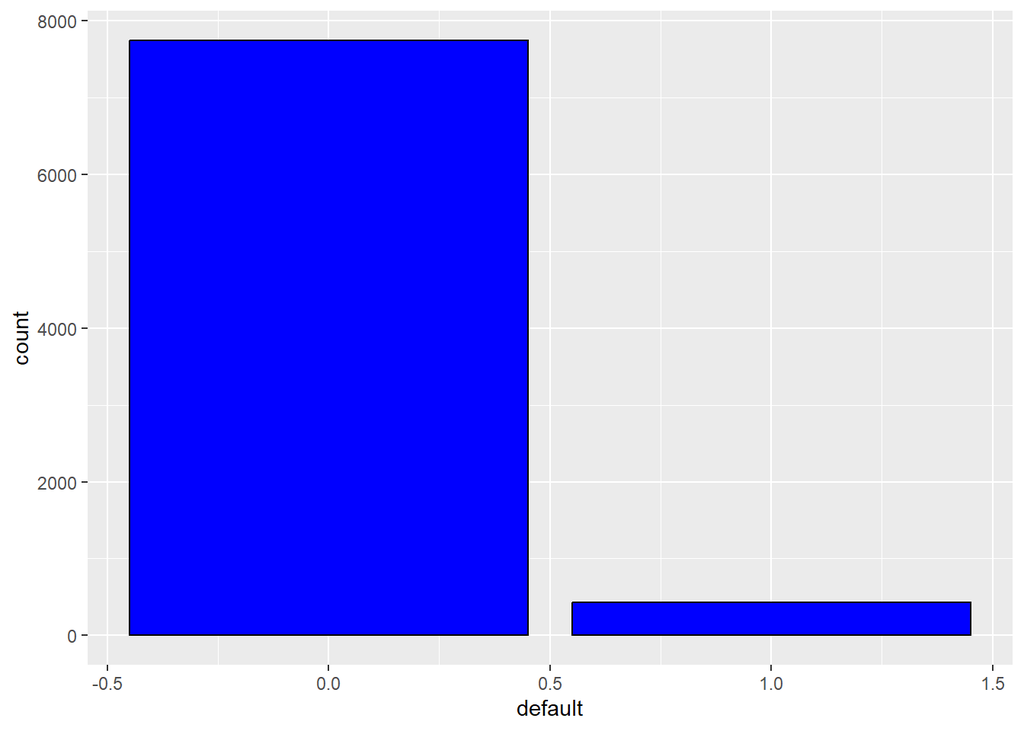

```r
# Barplots for categorical variables
ggplot(df, aes(x = default)) + geom_bar(fill = "blue", color = "black")
```

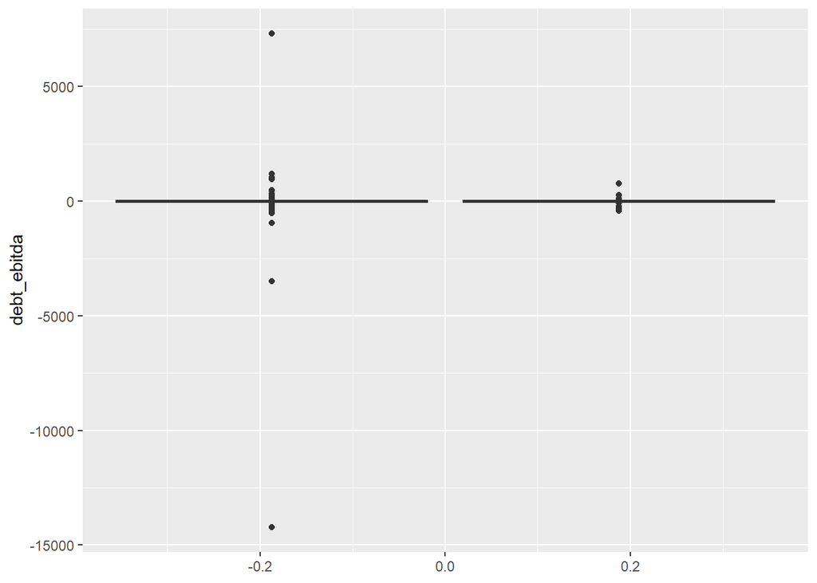

```r
# Boxplots for numeric variables by default
ggplot(df, aes(group = default, y = debt_ebitda)) + geom_boxplot()
```

## Plotting interesting features

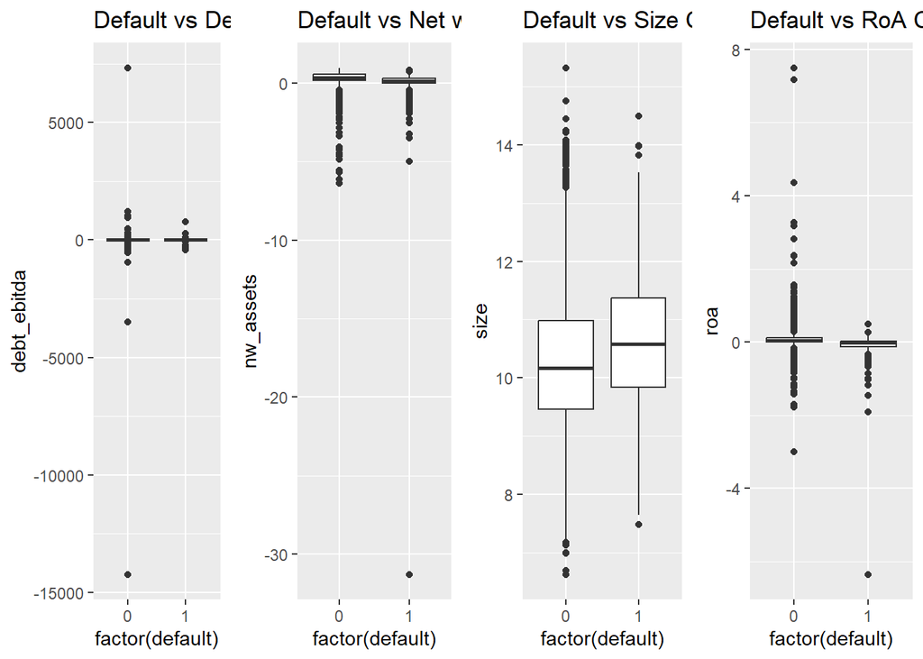

```r
p1 <- ggplot(df, aes(x = factor(default), y = debt_ebitda)) +
  geom_boxplot() +
  labs(title = "Default vs Debt / EBITDA Correlation")

p2 <- ggplot(df, aes(x = factor(default), y = nw_assets)) +
  geom_boxplot() +
  labs(title = "Default vs Net worth/Assets Correlation")

p3 <- ggplot(df, aes(x = factor(default), y = size)) +
  geom_boxplot() +
  labs(title = "Default vs Size Correlation")

p4 <- ggplot(df, aes(x = factor(default), y = roa)) +
  geom_boxplot() +
  labs(title = "Default vs RoA Correlation")

# Arrange plots in a grid
grid.arrange(p1, p2, p3, p4, ncol = 4)
```

```r
# There is some multicollinearity because of cash_assets
model_test <- glm(default ~ ., data = df)
summary(model_test)
```

```
##
## Call:
## glm(formula = default ~ ., data = df)
##
## Deviance Residuals:
##      Min        1Q    Median        3Q       Max
## -1.10412  -0.06897  -0.04762  -0.02312   1.00550
##
## Coefficients:
##                   Estimate Std. Error t value Pr(>|t|)
## (Intercept)     -4.531e-02  2.372e-02  -1.910  0.05616 .
## cash_assets     -1.177e-01  3.969e-02  -2.964  0.00304 **
## debt_ebitda      3.263e-06  1.312e-05   0.249  0.80356
## debt_assets      6.418e-02  1.251e-02   5.132 2.94e-07 ***
## roe             -3.645e-04  5.670e-04  -0.643  0.52042
## roa             -4.560e-02  1.427e-02  -3.194  0.00141 **
## intger_debt      5.956e-06  9.897e-06   0.602  0.54731
## size             1.066e-02  2.233e-03   4.774 1.84e-06 ***
## cap_debt         3.651e-04  5.600e-04   0.652  0.51438
## nw_assets       -3.283e-02  6.019e-03  -5.454 5.08e-08 ***
## intger_netdebt  -1.730e-05  2.560e-05  -0.676  0.49919
## int_cov          5.622e-05  4.381e-05   1.283  0.19941
## prftmrgn        -5.528e-02  1.313e-02  -4.209 2.59e-05 ***
## liquidity_ratio -4.942e-03  1.874e-03  -2.637  0.00837 **
## netdebt_intger   4.449e-05  3.025e-05   1.471  0.14141
## intger_debt2    -5.023e-05  1.332e-04  -0.377  0.70611
## cash_currntliab  9.694e-03  7.587e-03   1.278  0.20138
## ---
## Signif. codes:  0 '***' 0.001 '**' 0.01 '*' 0.05 '.' 0.1 ' ' 1
##
## (Dispersion parameter for gaussian family taken to be 0.04760356)
##
##     Null deviance: 407.37  on 8170  degrees of freedom
## Residual deviance: 388.16  on 8154  degrees of freedom
## AIC: -1672.2
##
## Number of Fisher Scoring iterations: 2
```

```r
data.frame(vif(model_test))
```

```
##                 vif.model_test.
## cash_assets            2.183907
## debt_ebitda            1.000628
## debt_assets            1.194683
## roe                    1.034314
## roa                    1.926591
## intger_debt            1.037670
## size                   1.109375
## cap_debt               1.003855
## nw_assets              1.801547
## intger_netdebt         1.000912
## int_cov                1.146827
## prftmrgn               1.854671
## liquidity_ratio        1.621599
## netdebt_intger         1.000910
## intger_debt2           1.001225
## cash_currntliab        2.805780
```

## Run various logistic models using 5-fold CV and selecting the best model

```r
# Define the outcome variable
outcome <- "default"

# Convert the outcome variable to a factor
df[[outcome]] <- as.factor(df[[outcome]])

# Generate valid variable names for factor levels
levels(df[[outcome]]) <- make.names(levels(df[[outcome]]))

# Define the predictor variables and the outcome
variables <- colnames(df[1:16])

data_subset <- df[, c(variables, outcome)]

# Define the control for the train function
ctrl <- trainControl(method = "cv", number = 5, classProbs = TRUE, summaryFunction = twoClassSummary,verboseIter = FALSE)

# Initialize variables to store the best model and the best AUC
best_model <- NULL
best_auc <- 0

# Fit a logistic regression model using stepwise variable selection
model_formula <- as.formula(paste(outcome, "~ ."))

# Fit a logistic regression model using 5-fold CV and compute the AUC
set.seed(123) # for reproducibility
best_logit <- train(model_formula, data = data_subset, method = "glmStepAIC", trControl = ctrl, metric = "ROC", na.action = na.omit)
```

[output not shown]

[output cut: 1058 more lines]

[output not shown]

```r
# Print the model
print(best_logit)
```

```
## Generalized Linear Model with Stepwise Feature Selection
##
## 8171 samples
##   16 predictor
##    2 classes: 'X0', 'X1'
##
## No pre-processing
## Resampling: Cross-Validated (5 fold)
## Summary of sample sizes: 6537, 6537, 6536, 6537, 6537
## Resampling results:
##
##   ROC        Sens       Spec
##   0.7645241  0.9970288  0.02093023
```

```r
summary(best_logit)
```

```
##
## Call:
## NULL
##
## Deviance Residuals:
##     Min       1Q   Median       3Q      Max
## -3.0028  -0.3558  -0.2807  -0.1903   4.4262
##
## Coefficients:
##                  Estimate Std. Error z value Pr(>|z|)
## (Intercept)     -4.739734   0.479834  -9.878  < 2e-16 ***
## debt_assets      0.484899   0.207203   2.340 0.019273 *
## roa             -2.230508   0.306934  -7.267 3.67e-13 ***
## size             0.233551   0.043491   5.370 7.87e-08 ***
## nw_assets       -0.252753   0.103697  -2.437 0.014792 *
## intger_netdebt  -0.002971   0.001658  -1.792 0.073208 .
## liquidity_ratio -0.370726   0.086479  -4.287 1.81e-05 ***
## cash_currntliab -1.696101   0.438920  -3.864 0.000111 ***
## ---
## Signif. codes:  0 '***' 0.001 '**' 0.01 '*' 0.05 '.' 0.1 ' ' 1
##
## (Dispersion parameter for binomial family taken to be 1)
##
##     Null deviance: 3369.3  on 8170  degrees of freedom
## Residual deviance: 3003.4  on 8163  degrees of freedom
## AIC: 3019.4
##
## Number of Fisher Scoring iterations: 8
```

## ROC analysis and AUROC of Logit model

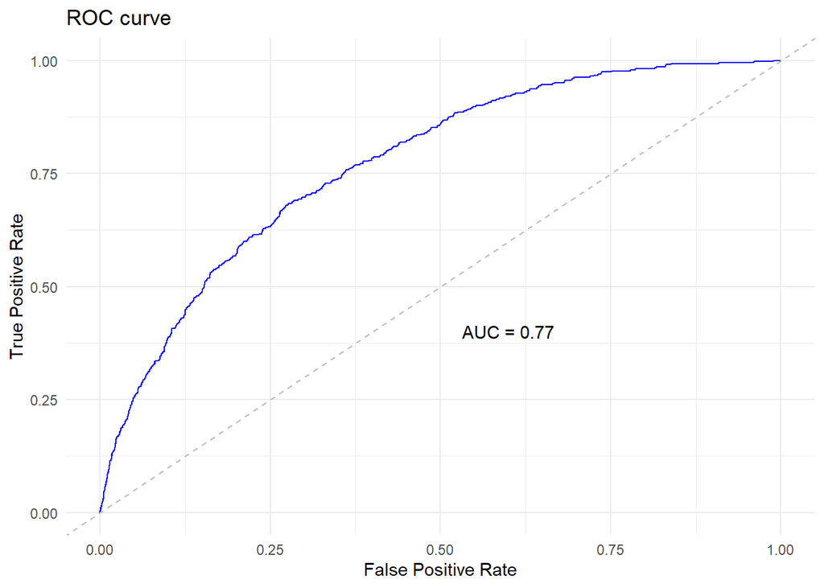

```r
#The Area Under the Receiver Operating Characteristic curve (AUROC) is a performance metric for binary classification problems. It measures the trade-off between sensitivity (true positive rate) and specificity (false positive rate) for every possible cutoff. An AUROC of 0.5 is no better than random guessing, while an AUROC of 1.0 signifies a perfect classifier. In general, an AUROC above 0.7 is considered acceptable, while an AUROC above 0.8 is considered good, and an AUROC above 0.9 is considered excellent. However, the acceptability of an AUROC value can depend on the specific application and the cost trade-off between false positives and false negatives. It's important to note that a high AUROC doesn't necessarily imply a useful model, especially if the positive class is very rare, or if the cost of a false positive is high.


# Make predictions on the validation set
pred <- predict(best_logit, newdata = data_subset, type = "prob")

# Compute the ROC curve
roc_obj <- pROC::roc(response = as.numeric(data_subset[[outcome]] == "X1"), predictor = pred[, "X1"])
# Compute the ROC curve
roc_obj <- pROC::roc(response = as.numeric(data_subset[[outcome]] == "X1"), predictor = pred[, "X1"])

# Convert the roc object to a data frame
roc_df <- data.frame(FPR = 1 - roc_obj$specificities, TPR = roc_obj$sensitivities)

# Create the ROC plot
ggplot(data = roc_df, aes(x = FPR, y = TPR)) +
  geom_line(color = "blue") +
  geom_abline(intercept = 0, slope = 1, linetype = "dashed", color = "gray") +
  ggtitle("ROC curve") +
  labs(x = "False Positive Rate", y = "True Positive Rate") +
  theme_minimal() +
  annotate("text", x = 0.6, y = 0.4, label = paste("AUC =", round(auc(roc_obj), 2)))
```

## Now let’s run some ML models to see if they can improve performance (Random Forest, Neural Net, SVM)

```r
# Define the control for the train function
ctrl <- trainControl(method = "cv", number = 5, classProbs = TRUE, summaryFunction = twoClassSummary)

# Define the model formula
model_formula <- as.formula(paste(outcome, "~ ."))

# Define a list of models to fit
models <- c("rf", "nnet", "svmLinear")

# Initialize a list to store the models
model_list <- list()

# Fit all models using 5-fold CV
for (model in models) {
  set.seed(123) # for reproducibility
  suppressWarnings({model_list[[model]] <- train(model_formula, data = data_subset, method = model, trControl = ctrl, metric = "ROC", na.action = na.omit)})
}
```

[output not shown]

```r
# Print the models
lapply(model_list, print)
```

```
## Random Forest
##
## 8171 samples
##   16 predictor
##    2 classes: 'X0', 'X1'
##
## No pre-processing
## Resampling: Cross-Validated (5 fold)
## Summary of sample sizes: 6537, 6537, 6536, 6537, 6537
## Resampling results across tuning parameters:
##
##   mtry  ROC        Sens       Spec
##    2    0.7735807  0.9987083  0.03720930
##    9    0.7673369  0.9972873  0.05116279
##   16    0.7655722  0.9967707  0.05581395
##
## ROC was used to select the optimal model using the largest value.
## The final value used for the model was mtry = 2.
## Neural Network
##
## 8171 samples
##   16 predictor
##    2 classes: 'X0', 'X1'
##
## No pre-processing
## Resampling: Cross-Validated (5 fold)
## Summary of sample sizes: 6537, 6537, 6536, 6537, 6537
## Resampling results across tuning parameters:
##
##   size  decay  ROC        Sens       Spec
##   1     0e+00  0.7149971  1.0000000  0.000000000
##   1     1e-04  0.6314120  1.0000000  0.000000000
##   1     1e-01  0.7805181  1.0000000  0.000000000
##   3     0e+00  0.7503130  0.9987087  0.009302326
##   3     1e-04  0.6952405  1.0000000  0.000000000
##   3     1e-01  0.7734919  0.9990956  0.011627907
##   5     0e+00  0.7469888  0.9987080  0.006976744
##   5     1e-04  0.7386560  0.9979328  0.020930233
##   5     1e-01  0.7660110  0.9985794  0.011627907
##
## ROC was used to select the optimal model using the largest value.
## The final values used for the model were size = 1 and decay = 0.1.
## Support Vector Machines with Linear Kernel
##
## 8171 samples
##   16 predictor
##    2 classes: 'X0', 'X1'
##
## No pre-processing
## Resampling: Cross-Validated (5 fold)
## Summary of sample sizes: 6537, 6537, 6536, 6537, 6537
## Resampling results:
##
##   ROC        Sens  Spec
##   0.6520486  1     0
##
## Tuning parameter 'C' was held constant at a value of 1
```

```
## $rf
##  mtry ROC         Sens        Spec
##  " 2" "0.7735807" "0.9987083" "0.03720930"
##  " 9" "0.7673369" "0.9972873" "0.05116279"
##  "16" "0.7655722" "0.9967707" "0.05581395"
##
## $nnet
##  size decay   ROC         Sens        Spec
##  "1"  "0e+00" "0.7149971" "1.0000000" "0.000000000"
##  "1"  "1e-04" "0.6314120" "1.0000000" "0.000000000"
##  "1"  "1e-01" "0.7805181" "1.0000000" "0.000000000"
##  "3"  "0e+00" "0.7503130" "0.9987087" "0.009302326"
##  "3"  "1e-04" "0.6952405" "1.0000000" "0.000000000"
##  "3"  "1e-01" "0.7734919" "0.9990956" "0.011627907"
##  "5"  "0e+00" "0.7469888" "0.9987080" "0.006976744"
##  "5"  "1e-04" "0.7386560" "0.9979328" "0.020930233"
##  "5"  "1e-01" "0.7660110" "0.9985794" "0.011627907"
##
## $svmLinear
##  ROC         Sens Spec
##  "0.6520486" "1"  "0"
```

```r
# Compare the performance of the models
results <- resamples(model_list)

# Print the summary of the results
summary(results)
```

```
##
## Call:
## summary.resamples(object = results)
##
## Models: rf, nnet, svmLinear
## Number of resamples: 5
##
## ROC
##                Min.   1st Qu.    Median      Mean   3rd Qu.      Max. NA's
## rf        0.7178242 0.7783149 0.7789120 0.7735807 0.7936422 0.7992103    0
## nnet      0.7438969 0.7591040 0.7924554 0.7805181 0.8016162 0.8055180    0
## svmLinear 0.4457364 0.5909651 0.7137763 0.6520486 0.7500150 0.7597500    0
##
## Sens
##               Min.   1st Qu.   Median      Mean  3rd Qu.     Max. NA's
## rf        0.998062 0.9980633 0.998708 0.9987083 0.999354 0.999354    0
## nnet      1.000000 1.0000000 1.000000 1.0000000 1.000000 1.000000    0
## svmLinear 1.000000 1.0000000 1.000000 1.0000000 1.000000 1.000000    0
##
## Spec
##                 Min.    1st Qu.     Median      Mean    3rd Qu.       Max. NA's
## rf        0.02325581 0.03488372 0.03488372 0.0372093 0.04651163 0.04651163    0
## nnet      0.00000000 0.00000000 0.00000000 0.0000000 0.00000000 0.00000000    0
## svmLinear 0.00000000 0.00000000 0.00000000 0.0000000 0.00000000 0.00000000    0
```

```r
# nnet and RF models improve AUROC, but they are more complex models.
```